# PISA 2015 - zadanie 3

Mateusz Kałamarz, Dorota Łępicka, Katarzyna Zdon

09 kwietnia 2017

# Statystyki krajów

W poniższym raporcie przedstawimy kilka analiz dla danych pochodzących z badania PISA w 2015r. Statystyki dotyczą głównie czasu rozwiązywania, liczy akcji oraz uzyskanych wyników zadań, które rozwiązywali uczniownie z podziałem na kraje.

### Podstawowe statystyki

Dla każdego pytania przedstawiliśmy podstawowe statystyki z podziałem na kraj. Kolumny oznaczają : nazwę pytania, kraj, ważony średni wynik, średnią, medianę, minimum i maksimum dla czasu oraz analogiczne stytystyki dla liczby akcji. (Jednostką dla czasu są sekundy.)

Przykładowe wyniki:

| item | CNT | mean_scor | mean_time | med_time | min_time | max_time | mean_n.actions | med_n.actions | min_n.actions | max_n.actions |
| --- | --- | --- | --- | --- | --- | --- | --- | --- | --- | --- |
| CM033Q01S | CZE | 0.85 | 55.06 | 47.73 | 14.96 | 336.27 | 4.65 | 3 | 3 | 37 |
| CM033Q01S | DEU | 0.84 | 48.71 | 43.38 | 5.46 | 227.33 | 5.07 | 3 | 3 | 166 |
| CM033Q01S | GBR | 0.79 | 44.05 | 40.01 | 6.10 | 229.43 | 4.58 | 3 | 3 | 63 |
| CM033Q01S | LTU | 0.74 | 52.67 | 46.48 | 7.35 | 238.87 | 4.89 | 3 | 3 | 35 |
| CM033Q01S | MAC | 0.83 | 47.25 | 41.74 | 10.05 | 475.97 | 5.98 | 4 | 3 | 87 |
| CM033Q01S | MNE | 0.63 | 66.24 | 58.49 | 13.43 | 335.39 | 5.56 | 3 | 3 | 113 |
| CM033Q01S | POL | 0.77 | 51.52 | 44.83 | 6.65 | 413.85 | 4.76 | 3 | 3 | 33 |
| CM033Q01S | RUS | 0.82 | 73.78 | 57.00 | 6.39 | 4776.40 | 5.51 | 3 | 3 | 121 |
| CM033Q01S | SVK | 0.77 | 63.50 | 54.38 | 10.00 | 514.50 | 4.88 | 3 | 3 | 65 |
| CM033Q01S | SWE | 0.85 | 48.81 | 44.26 | 14.68 | 198.61 | 4.23 | 3 | 3 | 31 |

Pełen zbiór statystyk znajduje się w pliku `statystyki.Rda`

### Czas rozwiązywania zadania

W dalszej analizie postanowiliśmy ograniczyć zbiór danych do poniższych krajów:

- Polska
- Korea Południowa
- Finlandia
- Grecja
- Brazylia
- Rosja
- Niemcy

Uczniów którzy rozwiązywali ostatnie zadanie dłużej niż 1h nie uwzględniamy w analizie. Zakładamy, że zrezygnowali z kontynuacji rozwiązywania testu przed upływem czasu.

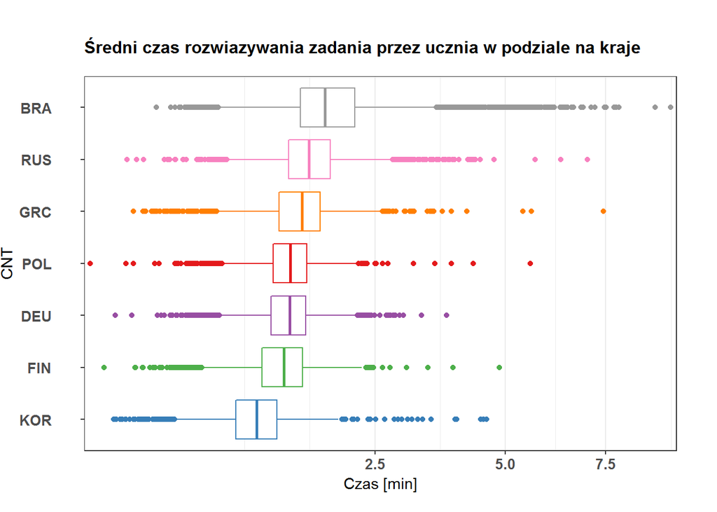

### Liczba akcji wykonywanych podczas rozwiązywania zadania

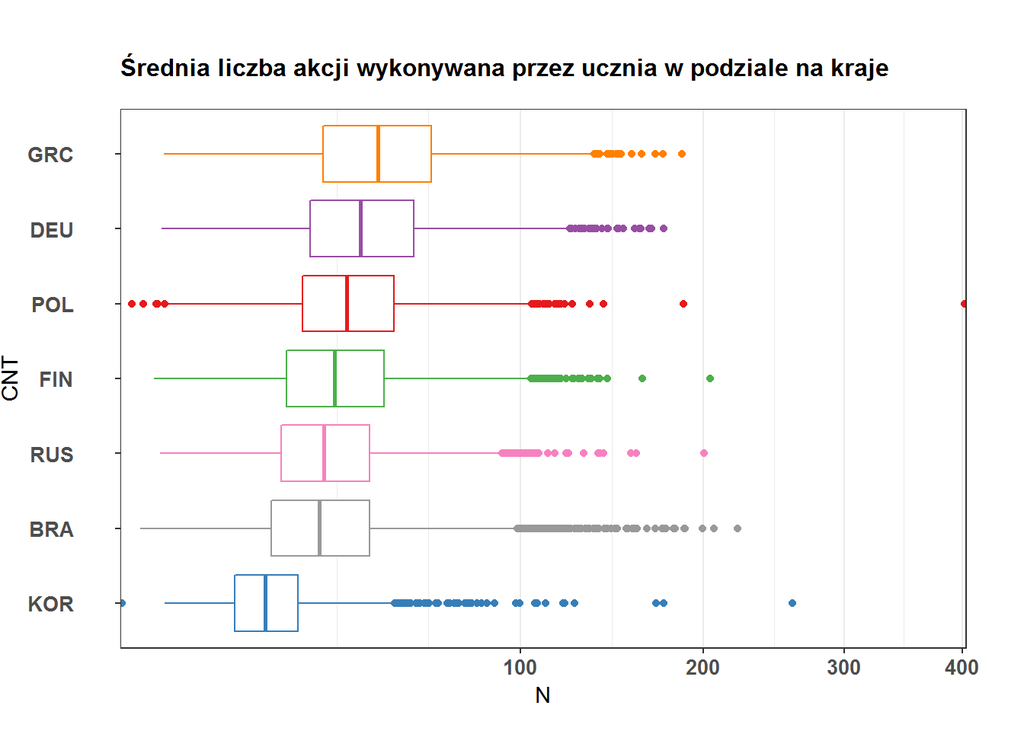

### Jak liczba akcji i czas rozwiązywania zadań przekłada się na wynik?

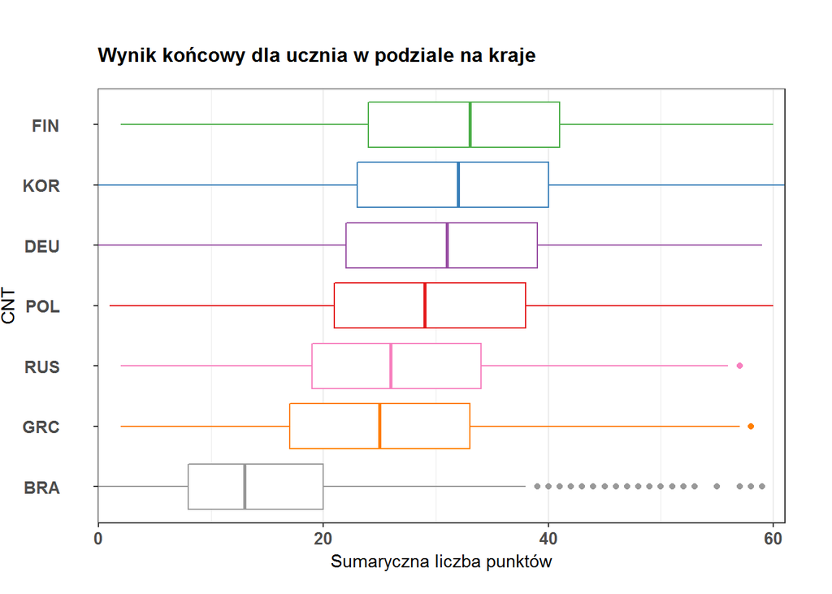

Z powyższych krajów znacząco wyróżnia się Brazylia. Charakteryzuje się najdłuższym czasem rozwiązywania zadań przez ucznia, który wykonuje przy tym małą liczbę akcji, uzyskując najsłabszy wynik wśród analizowanych krajów. Warto również zwrócić uwagę na Koreę. Uczniowie tego kraju szybko rozwiązują zadania i wykonują małą liczbę akcji, a uzyskają jeden z lepszych wyników. Polska na tle analizowanych krajów osiąga średnie wyniki we wszystkich kategoriach.

Możemy zauważyć zależność między średnim czasem rozwiązywania zadań a uzyskanym wynikiem. Im krótszy czas rozwiązywania zadań, tym uczeń osiaga lepsze wyniki.

### Czy płeć ma wpływ na wynik?

Przyjrzyjmy się teraz wykresom przedstawiającym średni ważony wyniki dla poszczególnych kategori zadań z podziałem na kraj i płeć. Na czerwono zostały zaznaczone analizowane szczegółowo kraje.

[interactive chart not shown]

Widzimy, że bez względu na kraj dziewczynki wypadają znacząco lepiej w czytaniu niż chłopcy. Ale czy ten trend utrzymuje się również dla zadań przyrodniczych i matematycznych?

[interactive chart not shown]

Dla zadań z matematyki chłopcy wypadają trochę lepiej od dziewcząt, ale różnica mieści się w progu $\pm$ 20punktów.

[interactive chart not shown]

Dla zadań przyrodniczych chłopcy i dziewczęta uzyskują podobne wyniki.

Najlepszy średni ważony wynik uzyskują uczniownie z Singapuru we wszystkich kategoriach.

### Kody

```r
# Podstawowe statystyki dla krajów

library(dplyr)
library(stringi)
library(ggplot2)
library(intsvy)
library(plotly)
library(tidyr)
load("dane_06_06.Rda")

dane <- dane %>%
  filter(!is.na(timing) & !is.na(n.actions) & !is.na(result))

dane$timing<-dane$timing/1000

statystyki<-dane %>%
  group_by(item, CNT) %>%
  summarise( mean_scor = round(weighted.mean(result, w=weights),2),
             mean_time= round(mean(timing),2),
             med_time = round(median(timing),2),
             min_time = round(min(timing),2),
             max_time = round(max(timing),2),
             mean_n.actions = round(mean(n.actions),2),
             med_n.actions = median(n.actions),
             min_n.actions = min(n.actions),
             max_n.actions = max(n.actions))

save(statystyki, file="statystyki.Rda")

# boxplot

dane <- dane %>% filter(stri_trim(CNT) %in% c("POL","BRA","FIN","DEU","GRC","KOR","RUS"))

zrezygnowali <- dane %>% select(CNTSTUID,  position, timing)%>%
  filter(timing>3600) %>%
  group_by(CNTSTUID) %>%
  mutate(maksymalny=max(as.numeric(position)))

zrezygnowali <- zrezygnowali %>% filter( maksymalny==position )

dane1 <- dane[-which(dane$CNTSTUID %in% zrezygnowali$CNTSTUID),]

dane1 <- dane1 %>% group_by(CNT,CNTSTUID) %>%
  summarise(mean_time=mean(timing), mean_action=mean(n.actions), final_result=sum(result))

save(dane1, file="dane1.Rda")

dane1$CNT<-reorder(dane1$CNT,dane1$mean_time, FUN=mean)

kolory <- c("#377eb8","#4daf4a","#984ea3","#e41a1c","#ff7f00","#f781bf","#999999")

ggplot(dane1, aes(x = CNT, y = mean_time/60, color = CNT)) +
  geom_boxplot(colour=kolory) +
  coord_flip(expand=TRUE)+
  ggtitle("Średni czas rozwiazywania zadania przez ucznia w podziale na kraje") +
  ylab("Czas [min]") +
  theme_bw() +
  theme(axis.text.x = element_text(hjust = 0.5,
                                   size=10,
                                   face="bold"),
        axis.text.y = element_text(hjust = 0.9,
                                   vjust=0.5,
                                   size=10,
                                   face="bold"),
        plot.title=element_text(margin=margin(b=0.5,
                                              unit="cm"),
                                hjust=0,
                                size=12,
                                face="bold"),
        panel.grid.major.y=element_blank(),
        plot.margin=unit(c(1,1,0.5,0), "cm"))+
  scale_y_sqrt(expand = c(0, 0.03))


dane1$CNT<-reorder(dane1$CNT,dane1$mean_action, FUN=mean)

kolory <- c("#377eb8","#999999","#f781bf","#4daf4a","#e41a1c","#984ea3","#ff7f00")

ggplot(dane1, aes(x = CNT, y = mean_action, color = CNT)) +
  geom_boxplot(colour=kolory) +
  coord_flip(expand=TRUE)+
  ggtitle("Średnia liczba akcji wykonywana przez ucznia w podziale na kraje") +
  ylab("N") +
  theme_bw() +
  theme(axis.text.x = element_text(hjust = 0.5,
                                   size=10,
                                   face="bold"),
        axis.text.y = element_text(hjust = 0.9,
                                   vjust=0.5,
                                   size=10,
                                   face="bold"),
        plot.title=element_text(margin=margin(b=0.5, unit="cm"),
                                hjust=0,
                                size=12,
                                face="bold"),
        panel.grid.major.y=element_blank(),
        plot.margin=unit(c(1,1,0.5,0), "cm"))+
  scale_y_sqrt(expand = c(0, 0.03))

dane1$CNT<-reorder(dane1$CNT,dane1$final_result, FUN=mean)
kolory<-c("#999999","#ff7f00","#f781bf","#e41a1c","#984ea3","#377eb8","#4daf4a")

ggplot(dane1, aes(x = CNT, y = final_result, color = CNT)) +
  geom_boxplot(colour=kolory) +
  coord_flip(expand=TRUE)+
  ggtitle("Wynik końcowy dla ucznia w podziale na kraje") +
  ylab("Sumaryczna liczba punktów") +
  theme_bw() +
  theme(axis.text.x = element_text(hjust = 0.5,
                                   size=10,
                                   face="bold"),
        axis.text.y = element_text(hjust = 0.9,
                                   vjust=0.5,
                                   size=10,
                                   face="bold"),
        plot.title=element_text(margin=margin(b=0.5, unit="cm"),
                                hjust=0,
                                size=12,
                                face="bold"),
        panel.grid.major.y=element_blank(),
        plot.margin=unit(c(1,1,0.5,0), "cm"))+
  scale_y_continuous(expand = c(0, 0.03))

# Podział na płeć

questions <- read.spss("CY6_MS_CMB_STU_QQQ.sav", use.value.labels = TRUE, to.data.frame = TRUE)

questions<- questions %>%
  filter(stri_trim(CNT) %in% c("POL","BRA","FIN","DEU","GRC","KOR","RUS"))

save(questions, file="questions.Rda")

load("questions.Rda")

config <- list(variables = list(pvlabelpref = "PV",
                                   pvlabelsuff = "READ",
                                   weightFinal = "W_FSTUWT",
                                   weightBRR = "W_FSTURWT"),
                  parameters = list(cutoffs = c(357.77, 420.07, 482.38, 544.68,                                      606.99, 669.30),
                                    percentiles = c(5, 10, 25, 75, 90, 95),
                                    PVreps = 10, BRRreps = 80,
                                    weights = "BRR",
                                    replication_scheme = 'pisa'))


gender_read <- intsvy.mean.pv(pvnames = paste("PV", 1:10, "READ", sep=""),
                             by=c("CNT", "ST004D01T"), data=questions,
                             name="output", folder=getwd(), config=config)

gender_read <- gender_read[,c(1,2,4,5)]

gender_read <- gender_read %>%
  select(CNT, ST004D01T, Mean) %>%
  spread(ST004D01T, Mean)

save(gender_read, file="gender_read.Rda")

kraje <- gender_read %>%
  filter(stri_trim(CNT) %in% c("POL","BRA","FIN","DEU","GRC","KOR","RUS"))

pl <- ggplot(gender_read, aes(Female, Male, text=paste("Kraj:",CNT),color=CNT)) +
  geom_point() +
  geom_point(data=kraje, color="red",size=3) +
  geom_abline(slope=1, intercept = 0) +
  geom_abline(slope=1, intercept = 20, linetype = 2, color="grey") +
  geom_abline(slope=1, intercept = -20, linetype = 2, color="grey") +
  coord_fixed(xlim = c(300,570), ylim = c(300,570)) +
  theme_classic() + ggtitle("Wynik dla czytania w podziale na płeć") +
  xlab("Wynik dla dziewcząt") +
  ylab("Wynik dla chłopców")+
  theme(legend.position="none")

pl %>% ggplotly(originalData = FALSE,tooltip=c("text", "Female", "Male"), legend=FALSE)

config <- list(variables = list(pvlabelpref = "PV",
                                   pvlabelsuff = "MATH",
                                   weightFinal = "W_FSTUWT",
                                   weightBRR = "W_FSTURWT"),
                  parameters = list(cutoffs = c(357.77, 420.07, 482.38, 544.68,                                      606.99, 669.30),
                                    percentiles = c(5, 10, 25, 75, 90, 95),
                                    PVreps = 10, BRRreps = 80,
                                    weights = "BRR",
                                    replication_scheme = 'pisa'))


gender_math <- intsvy.mean.pv(pvnames = paste("PV", 1:10, "MATH", sep=""),
                             by=c("CNT", "ST004D01T"), data=questions,
                             name="output", folder=getwd(), config=config)

gender_math <- gender_math[,c(1,2,4,5)]

gender_math <- gender_math %>%
  select(CNT, ST004D01T, Mean) %>%
  spread(ST004D01T, Mean)

save(gender_math, file="gender_math.Rda")

kraje <- gender_math %>%
  filter(stri_trim(CNT) %in% c("POL","BRA","FIN","DEU","GRC","KOR","RUS"))


pl <- ggplot(gender_math, aes(Female, Male, text=paste("Kraj:",CNT),color=CNT)) +
  geom_point() +
  geom_point(data=kraje, color="red",size=3) +
  geom_abline(slope=1, intercept = 0) +
  geom_abline(slope=1, intercept = 20, linetype = 2, color="grey") +
  geom_abline(slope=1, intercept = -20, linetype = 2, color="grey") +
  coord_fixed(xlim = c(300,570), ylim = c(300,570)) +
  theme_classic() + ggtitle("Wynik dla zadań matematycznych w podziale na płeć") +
  xlab("Wynik dla dziewcząt") +
  ylab("Wynik dla chłopców")+
  theme(legend.position="none")

pl %>% ggplotly(originalData = FALSE,tooltip=c("text", "Female", "Male"), legend=FALSE)


config <- list(variables = list(pvlabelpref = "PV",
                                   pvlabelsuff = "SCIE",
                                   weightFinal = "W_FSTUWT",
                                   weightBRR = "W_FSTURWT"),
                  parameters = list(cutoffs = c(357.77, 420.07, 482.38, 544.68,                                      606.99, 669.30),
                                    percentiles = c(5, 10, 25, 75, 90, 95),
                                    PVreps = 10, BRRreps = 80,
                                    weights = "BRR",
                                    replication_scheme = 'pisa'))


gender_science <- intsvy.mean.pv(pvnames = paste("PV", 1:10, "SCIE", sep=""),
                             by=c("CNT", "ST004D01T"), data=questions,
                             name="output", folder=getwd(), config=config)

gender_science <- gender_science[,c(1,2,4,5)]

gender_science <- gender_science %>%
  select(CNT, ST004D01T, Mean) %>%
  spread(ST004D01T, Mean)

save(gender_science, file="gender_science.Rda")


kraje <- gender_science %>% filter(stri_trim(CNT) %in% c("POL","BRA","FIN","DEU","GRC","KOR","RUS"))

pl <- ggplot(gender_science, aes(Female, Male, text=paste("Kraj:",CNT),color=CNT)) +
  geom_point() +
  geom_point(data=kraje, color="red",size=3) +
  geom_abline(slope=1, intercept = 0) +
  geom_abline(slope=1, intercept = 20, linetype = 2, color="grey") +
  geom_abline(slope=1, intercept = -20, linetype = 2, color="grey") +
  coord_fixed(xlim = c(300,570), ylim = c(300,570)) +
  theme_classic() + ggtitle("Wynik dla zadań przyrodniczych w podziale na płeć") +
  xlab("Wynik dla dziewcząt") +
  ylab("Wynik dla chłopców")+
  theme(legend.position="none")

pl %>% ggplotly(originalData = FALSE,tooltip=c("text", "Female", "Male"), legend=FALSE)
```